# Sales Example

Alexandra Chronopoulou

Lecture 11 Time Series Example

A company wants to predict its sales by using industry sales that are available from the industry’s trade association, as a predictor.

```r
sales <- read.table("Sales.txt", header=FALSE)
names(sales)=c("company_sales", "industry_sales")
sales$index = seq(1:dim(sales)[1])
head(sales)
```

```
##   company_sales industry_sales index
## 1         20.96          127.3     1
## 2         21.40          130.0     2
## 3         21.96          132.7     3
## 4         21.52          129.4     4
## 5         22.39          135.0     5
## 6         22.76          137.1     6
```

We start by fitting a simple linear regression

```r
lm.sales = lm(company_sales~industry_sales, data=sales)
summary(lm.sales)
```

```
##
## Call:
## lm(formula = company_sales ~ industry_sales, data = sales)
##
## Residuals:
##       Min        1Q    Median        3Q       Max
## -0.149142 -0.054399 -0.000454  0.046425  0.163754
##
## Coefficients:
##                 Estimate Std. Error t value Pr(>|t|)
## (Intercept)    -1.454750   0.214146  -6.793 2.31e-06 ***
## industry_sales  0.176283   0.001445 122.017  < 2e-16 ***
## ---
## Signif. codes:  0 '***' 0.001 '**' 0.01 '*' 0.05 '.' 0.1 ' ' 1
##
## Residual standard error: 0.08606 on 18 degrees of freedom
## Multiple R-squared:  0.9988, Adjusted R-squared:  0.9987
## F-statistic: 1.489e+04 on 1 and 18 DF,  p-value: < 2.2e-16
```

The fit of the model looks great!? All the p-values are low, indicating that the industry sales indeed explain the variation in the response and the $R^2$ is extremely high.

Let’s take a closer look at the model and check the residual plots:

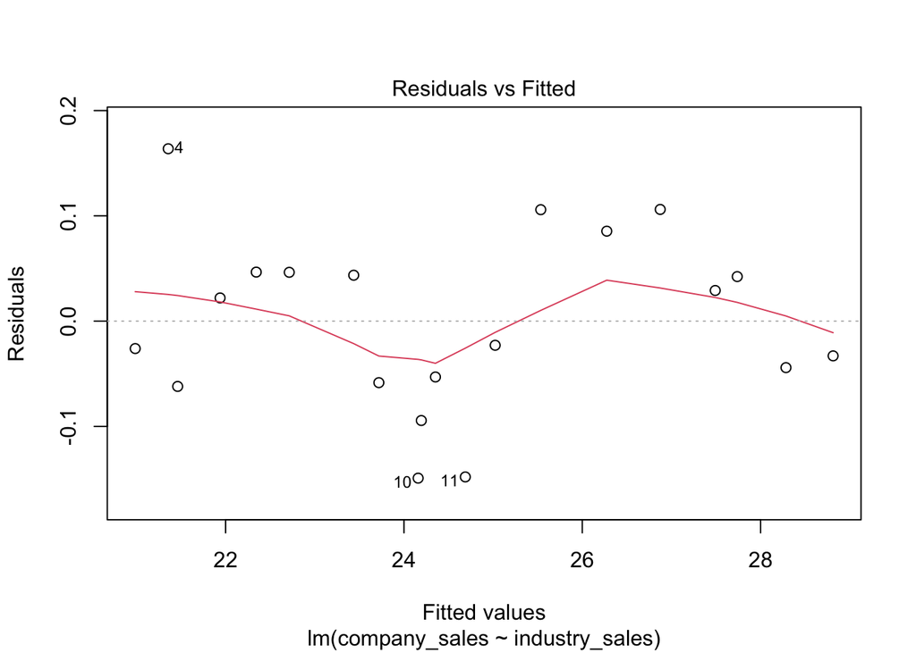

```r
plot(lm.sales, which=1)
```

Let’s also plot the residuals against time (the index column in the data frame):

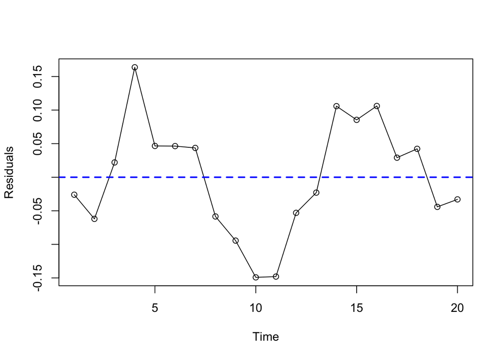

```r
plot(lm.sales$residuals ~ sales$index, type='o', xlab="Time", ylab="Residuals")
abline(h=0, lty=2, col="blue", lwd=2)
```

The sequence plot suggest a pattern in the residuals. Let us confirm that via a proper hypothesis test, such as the Durbin-Watson test:

```r
library(lmtest)
dwtest(lm.sales)
```

```
##
##  Durbin-Watson test
##
## data:  lm.sales
## DW = 0.73473, p-value = 0.0001748
## alternative hypothesis: true autocorrelation is greater than 0
```

Based on the p-value of the DW test, we conclude that the error terms are *positively auto-correlated*.

We can now use this to information to fit a regression with autocorrelated errors. In fact, the model we are going to fit looks like
$$y_i = \beta_0 + \beta_1 y_i + \varepsilon_i$$
where
$$\varepsilon_i = \rho \; \varepsilon_{i-1} + u_i$$
where the $u_i$ terms are independent normal variables (called disturbances) with mean 0 and variance $\sigma^2$. This implies that any error term is the sum of the previous error term and a new disturbance term. The parameter $\rho$ is called the *autocorrelation* parameter. The model we assumed for the error terms is called a *first order autoregressive model*, in short AR(1).

In order to fit such a model in R, we use the `gls` function in the `nlme` package as follows:

```r
library(nlme)
lm.sales.cor = gls(company_sales~industry_sales, correlation = corAR1(form= ~ index), data=sales)
```

Below is the summary output for the new regression model. It is different than the output we are used to obtain with the `lm` function, but it contains the information about model estimates, st. errors and t test, as will as the estimated $\rho$ coefficient (called phi in R) as well as the estimated variance.

```r
summary(lm.sales.cor)
```

```
## Generalized least squares fit by REML
##   Model: company_sales ~ industry_sales
##   Data: sales
##         AIC       BIC   logLik
##   -31.74311 -28.18162 19.87156
##
## Correlation Structure: AR(1)
##  Formula: ~index
##  Parameter estimate(s):
## Phi
##   1
##
## Coefficients:
##                     Value Std.Error  t-value p-value
## (Intercept)    -0.3189197 2041.6945 -0.00016  0.9999
## industry_sales  0.1684878    0.0051 33.06272  0.0000
##
##  Correlation:
##                (Intr)
## industry_sales 0
##
## Standardized residuals:
##           Min            Q1           Med            Q3           Max
## -9.036061e-05 -4.156415e-05 -3.013053e-06  8.080346e-05  1.091922e-04
##
## Residual standard error: 2041.694
## Degrees of freedom: 20 total; 18 residual
```

Because of the complexity of the model, all parameters are estimated using a different method called *Restricted Maximum Likelihood*. The details of this method are beyond the scope of the course.